# Pyhton Notes

# Other Builtin functions

```python
A
```

```
{1, 2, 3, 4, 5, 6, 7, 8, 9}
```

```python
sum(A)
```

```
45
```

```python
max(A)
```

```
9
```

```python
min(A)
```

```
1
```

```python
len(A)
```

```
9
```

```python
list(enumerate(A))
```

```
[(0, 1), (1, 2), (2, 3), (3, 4), (4, 5), (5, 6), (6, 7), (7, 8), (8, 9)]
```

```python
D=sorted(A, reverse=True)
D
```

```
[9, 8, 7, 6, 5, 4, 3, 2, 1]
```

```python
sorted(D)
```

```
[1, 2, 3, 4, 5, 6, 7, 8, 9]
```

# Dictionary

Dictionary is a mutable data type in Python.

A python dictionary is a collection of key and value pairs separated by a colon (:) & enclosedin curly braces {}.

Keys must be unique in a dictionary, duplicate values are allowed.

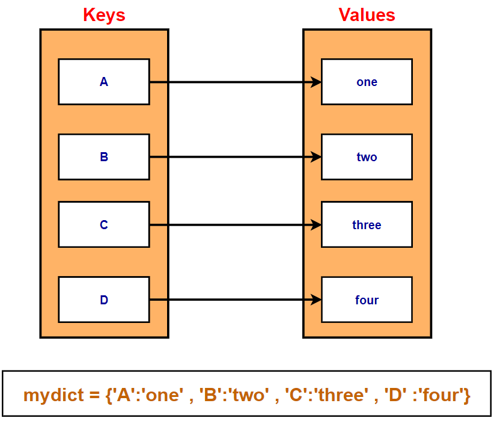

# Create Dictionary

```python
 mydict={}         # empty dictionary
 mydict
```

```
{}
```

```python
mydict={1:'one', 2:'two', 3:'three'}     #dictionary with integer keys
mydict
```

```
{1: 'one', 2: 'two', 3: 'three'}
```

```python
mydict=dict({1:'one', 2:'two', 3:'three'})      # Create dictionary using dict()
mydict
```

```
{1: 'one', 2: 'two', 3: 'three'}
```

```python
mydict={'A':'one','B':'two','C':'three'}                 # dictionary with character keys
mydict
```

```
{'A': 'one', 'B': 'two', 'C': 'three'}
```

```python
mydict={1:'one','B':'two','C':'three'}                 # dictionary with Mixed keys
mydict
```

```
{1: 'one', 'B': 'two', 'C': 'three'}
```

```python
mydict.keys()                                     # Return Dictionary Keys using keys() method
```

```
dict_keys([1, 'B', 'C'])
```

```python
mydict.values()                                      # Return Dictionary Values using values() method
```

```
dict_values(['one', 'two', 'three'])
```

```python
mydict.items()                           # Access each key-value pair within a dictionary
```

```
dict_items([(1, 'one'), ('B', 'two'), ('C', 'three')])
```

```python
mydict={1:'one',2:'two','A':['asif','john','Maria']}  # dictionary with other sequtial datatypes eg List
mydict
```

```
{1: 'one', 2: 'two', 'A': ['asif', 'john', 'Maria']}
```

```python
keys={'a','b','c','d'}
value=10
mydict3=dict.fromkeys(keys,value)   # Create a dictionary from a sequence of k
mydict3
```

```
{'a': 10, 'd': 10, 'c': 10, 'b': 10}
```

```python
keys={'a','b','c','d'}
value=[10,20,30]
mydict3=dict.fromkeys(keys,value)    # Create a dictionary from a sequence of k
mydict3
```

```
{'a': [10, 20, 30], 'd': [10, 20, 30], 'c': [10, 20, 30], 'b': [10, 20, 30]}
```

```python
value.append(40)
```

```python
mydict3
```

```
{'a': [10, 20, 30, 40],
 'd': [10, 20, 30, 40],
 'c': [10, 20, 30, 40],
 'b': [10, 20, 30, 40]}
```

# Accessing Items

```python
mydict={1:'one',2:'two',3:'three',4:'four'}
mydict
```

```
{1: 'one', 2: 'two', 3: 'three', 4: 'four'}
```

```python
mydict[1]   # Access item using key
```

```
'one'
```

```python
mydict.get(1)  # Access item using get() method
```

```
'one'
```

```python
mydict1={'Name':'John','ID':74123,'DOB':1991,'job':'Analyst'}
mydict1
```

```
{'Name': 'John', 'ID': 74123, 'DOB': 1991, 'job': 'Analyst'}
```

```python
mydict1['Name']     # Access item using key
```

```
'John'
```

```python
mydict1.get('job')   # Access item using get() method
```

```
'Analyst'
```

# Add, Remove & Change Items

```python
mydict1={'Name':'John','ID':74123,'DOB':1991,'Address':'Helshiki'}
mydict1
```

```
{'Name': 'John', 'ID': 74123, 'DOB': 1991, 'Address': 'Helshiki'}
```

```python
mydict1['DOB'] =1992                                                  # updating items in the dictionary
mydict1["Address"]='Chennai'
mydict1
```

```
{'Name': 'John', 'ID': 74123, 'DOB': 1992, 'Address': 'Chennai'}
```

```python
mydict1.update({'DOB':1995})
mydict1
```

```
{'Name': 'John', 'ID': 74123, 'DOB': 1995, 'Address': 'Chennai'}
```

```python
mydict1['Job']="Data Analysist"                                      # Adding items in the dictionary
mydict1
```

```
{'Name': 'John',
 'ID': 74123,
 'DOB': 1995,
 'Address': 'Chennai',
 'Job': 'Data Analysist'}
```

```python
mydict1.pop('Job') # Removing items in the dictionary using Pop method
mydict1
```

```
{'Name': 'John', 'ID': 74123, 'DOB': 1995, 'Address': 'Chennai'}
```

```python
mydict1.popitem()# A last item item is removed
```

```
('Address', 'Chennai')
```

```python
del mydict1['ID']                  # Removing item using del method
mydict1
```

```
{'Name': 'John', 'DOB': 1995}
```

```python
 mydict1.clear()
mydict1
```

```
{}
```

```python
del mydict1
mydict1
```

```
---------------------------------------------------------------------------
NameError                                 Traceback (most recent call last)
~\AppData\Local\Temp/ipykernel_11208/1059459225.py in <module>
      1 del mydict1
----> 2 mydict1

NameError: name 'mydict1' is not defined
```

# Copy Dictionary

```python
mydict={'Name':'John','ID':74123,'DOB':1991,'Address':'Helshiki'}
mydict
```

```
{'Name': 'John', 'ID': 74123, 'DOB': 1991, 'Address': 'Helshiki'}
```

```python
mydict1=mydict                         # Create a new reference "mydict1"
mydict1
```

```
{'Name': 'John', 'ID': 74123, 'DOB': 1991, 'Address': 'Helshiki'}
```

```python
id(mydict), id(mydict1)               # The address of both mydict & mydict1 will be the same
```

```
(1438846704320, 1438846704320)
```

```python
mydict2=mydict1.copy()               # Create a copy of the dictionary
```

```python
id(mydict), id(mydict1),id(mydict2)  # The address of mydict2 will be different from mydict because mydict2
                                     #   is not refrence
```

```
(1869566571264, 1869566571264, 1869600672384)
```

```python
mydict
```

```
{'Name': 'John', 'ID': 74123, 'DOB': 1991, 'Address': 'Helshiki'}
```

```python
mydict['Address']='Mumbai'
mydict
```

```
{'Name': 'John', 'ID': 74123, 'DOB': 1991, 'Address': 'Mumbai'}
```

```python
mydict1  # mydict1 will be also impacted as it is pointing to the same dictionary
```

```
{'Name': 'John', 'ID': 74123, 'DOB': 1991, 'Address': 'Mumbai'}
```

```python
mydict2  # Copy of dictonary won't be impacted due to the changes made in the original
```

```
{'Name': 'John', 'ID': 74123, 'DOB': 1991, 'Address': 'Helshiki'}
```

# Loop through a Dictionary

```python
mydict1={'Name':'John', 'ID':12345, 'DOB':1991, 'Address':'Hilsinki', 'Job': 'Analyst'}
mydict1
```

```
{'Name': 'John',
 'ID': 12345,
 'DOB': 1991,
 'Address': 'Hilsinki',
 'Job': 'Analyst'}
```

```python
for i in mydict1:
    print(i, ':',mydict1[i])   # Key & value pair
```

```
Name : John
ID : 12345
DOB : 1991
Address : Hilsinki
Job : Analyst
```

```python
for i in mydict1:
    print(mydict1[i]) # only  items
```

```
John
12345
1991
Hilsinki
Analyst
```

# Dictionary Membership

```python
mydict1={'Name':'John', 'ID':12345, 'DOB':1991, 'Address':'Hilsinki', 'Job': 'Analyst'}
mydict1
```

```
{'Name': 'John',
 'ID': 12345,
 'DOB': 1991,
 'Address': 'Hilsinki',
 'Job': 'Analyst'}
```

```python
'Name' in mydict1             #Test if a key is in a dictionary or not.
```

```
True
```

```python
'Asif'  in mydict1          # Membership test can be only done for keys.
```

```
False
```

```python
'ID'  in mydict1
```

```
True
```

```python
'Address'  in mydict1
```

```
True
```

# All / Any

The all() method returns: True

```python
mydict1={'Name':'John', 'ID':12345, 'DOB':1991, 'Address':'Hilsinki', 'Job': 'Analyst'}
mydict1
```

```
{'Name': 'John',
 'ID': 12345,
 'DOB': 1991,
 'Address': 'Hilsinki',
 'Job': 'Analyst'}
```

```python
all(mydict1)
```

```
True
```

```python
any(mydict1)
```

```
True
```

```python
mydict1[0]='test'
mydict1
```

```
{'Name': 'John',
 'ID': 12345,
 'DOB': 1991,
 'Address': 'Hilsinki',
 'Job': 'Analyst',
 0: 'test'}
```

```python
all(mydict1)
```

```
False
```

```python
any(mydict1)
```

```
True
```

```python
mydict1={ 0:'test', 1:'test1', 2:'test3'}
mydict1
```

```
{0: 'test', 1: 'test1', 2: 'test3'}
```

```python
all(mydict1)
```

```
False
```

```python
any(mydict1)
```

```
True
```

# Dictionary Comprehension

```python
double={i:i*2 for i in range(10)}
double
```

```
{0: 0, 1: 2, 2: 4, 3: 6, 4: 8, 5: 10, 6: 12, 7: 14, 8: 16, 9: 18}
```

```python
squre={i:i**2 for i in range(10)}
squre
```

```
{0: 0, 1: 1, 2: 4, 3: 9, 4: 16, 5: 25, 6: 36, 7: 49, 8: 64, 9: 81}
```

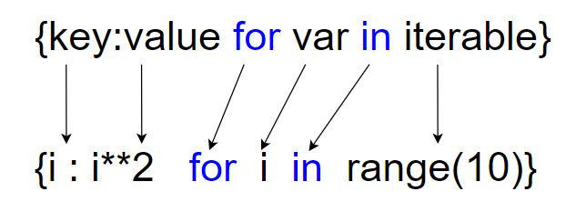

```python
key=['one', 'two', 'three', 'four']
value=[1,2,3,4,5]
```

```python
mydict={k:v for k,v in zip(key,value)}
mydict
```

```
{'one': 1, 'two': 2, 'three': 3, 'four': 4}
```

```python
mydict1={ k:v/10 for k,v in mydict.items()}
mydict1
```

```
{'one': 0.1, 'two': 0.2, 'three': 0.3, 'four': 0.4}
```

```python
str1="Natural Language Processing"

mydict1={ k:v for k,v in enumerate(str1)} # Store enumerated values in a dictionary
mydict1
```

```
{0: 'N',
 1: 'a',
 2: 't',
 3: 'u',
 4: 'r',
 5: 'a',
 6: 'l',
 7: ' ',
 8: 'L',
 9: 'a',
 10: 'n',
 11: 'g',
 12: 'u',
 13: 'a',
 14: 'g',
 15: 'e',
 16: ' ',
 17: 'P',
 18: 'r',
 19: 'o',
 20: 'c',
 21: 'e',
 22: 's',
 23: 's',
 24: 'i',
 25: 'n',
 26: 'g'}
```

```python
str1="abcdefghijklmnopqrstuvwxyz"

mydict1={ i:i.upper() for i in str1} # Lowercase to UPPER case
mydict1
```

```
{'a': 'A',
 'b': 'B',
 'c': 'C',
 'd': 'D',
 'e': 'E',
 'f': 'F',
 'g': 'G',
 'h': 'H',
 'i': 'I',
 'j': 'J',
 'k': 'K',
 'l': 'L',
 'm': 'M',
 'n': 'N',
 'o': 'O',
 'p': 'P',
 'q': 'Q',
 'r': 'R',
 's': 'S',
 't': 'T',
 'u': 'U',
 'v': 'V',
 'w': 'W',
 'x': 'X',
 'y': 'Y',
 'z': 'Z'}
```

# Word Frequency using dictionary

```python
mystr4="one two three four one two three four one two two three five five six seven six seven"
```

```python
mylist=mystr4.split()       # Split String into substrings
mylist
```

```
['one',
 'two',
 'three',
 'four',
 'one',
 'two',
 'three',
 'four',
 'one',
 'two',
 'two',
 'three',
 'five',
 'five',
 'six',
 'seven',
 'six',
 'seven']
```

```python
mylist1=set(mylist)               # Unique values in a list
mylist1=list(mylist1)
mylist1
```

```
['one', 'four', 'six', 'five', 'two', 'seven', 'three']
```

```python
for i in mylist1:
   print(f"{i}: {mylist.count(i)}")
```

```
one: 3
four: 2
six: 2
five: 2
two: 4
seven: 2
three: 3
```

```python
{i:mylist.count(i) for i in mylist1 }
```

```
{'one': 3, 'four': 2, 'six': 2, 'five': 2, 'two': 4, 'seven': 2, 'three': 3}
```

# Operators

Operators are special symbols in Python which are used to perform operations onvariables/values.

# Arithmetic Operators

```python
a = 5
b = 2
x = 'John'
y = 'Smith'
# Addition
c = a + b
print(f"Addition of  a as {a} and b as  {b} will give (a + b) as  :- {c}\n")
#Concatenate string using plus operator
z = x+y
print (f"Concatenate string  x as {x} and y as {y} using \'+\' operaotr for concdinate and give  :- {z}\n")

# Subtraction
c = a - b
print(f"Subtracting a as {a} and b as  {b} will give (a - b) as  :- {c}\n")

# Multiplication
c = a * b
print(f"Multiplying a as {a} and b as  {b} will give (a * b) as  :- {c}\n")

# Division
c = a / b
print(f"Dividing a as {a} and b as  {b} will give (a / b) as  :- {c}\n")

# Modulo of both number
c = a % b
print(f"Modulo of a as  {a} , b as {b} will give :- {c}\n")

# Power
c = a ** b
print(f"a as {a} raised to the power b as {b} will give :- {c}\n")
# Division(floor)
c = a // b
print(f"Floor division of a as {a} by b as {b} will give :- {c}\n")
```

```
Addition of  a as 5 and b as  2 will give (a + b) as  :- 7

Concatenate string  x as John and y as Smith using '+' operaotr for concdinate and give  :- JohnSmith

Subtracting a as 5 and b as  2 will give (a - b) as  :- 3

Multiplying a as 5 and b as  2 will give (a * b) as  :- 10

Dividing a as 5 and b as  2 will give (a / b) as  :- 2.5

Modulo of a as  5 , b as 2 will give :- 1

a as 5 raised to the power b as 2 will give :- 25

Floor division of a as 5 by b as 2 will give :- 2
```

# Comparison Operators

Comparison operators are used to compare values.

```python
x = 20
y = 30
print('Is x greater than y :- ',x>y)
print('\nIs x less than y :- ',x<y)
print('\nIs x equal to y :- ',x==y)
print('\nIs x not equal to y :- ',x!=y)
print('\nIs x greater than or equal to y :- ',x>=y)
print('\nIs x less than or equal to y :- ',x<=y)
```

```
Is x greater than y :-  False

Is x less than y :-  True

Is x equal to y :-  False

Is x not equal to y :-  True

Is x greater than or equal to y :-  False

Is x less than or equal to y :-  True
```

```python
a = 'John'
b = 'smith'
c = 'coder'
a == b , a ==c , a != b # Comparison operators on string
```

```
(False, False, True)
```

# Logical Operators

```python
x = True
y = False
print('Logical AND operation :- ',x and y) # True if both values are true
print('Logical OR operation :- ',x or y) # True if either of the values is true
print('NOT operation :- ',not x ) # True if operand is false
```

```
Logical AND operation :-  False
Logical OR operation :-  True
NOT operation :-  False
```

# Bitwise operators

# Bitwise operators act on bits and performs bit by bit operation.

```python
#!/usr/bin/python3
a = 60 # 60 = 0011 1100
b = 13 # 13 = 0000 1101
print ('a=',a,':',bin(a),'b=',b,':',bin(b))
c = 0
c = a & b; # 12 = 0000 1100
print ("result of AND is ", c,':',bin(c))
c = a | b; # 61 = 0011 1101
print ("result of OR is ", c,':',bin(c))
```

```
a= 60 : 0b111100 b= 13 : 0b1101
result of AND is  12 : 0b1100
result of OR is  61 : 0b111101
```

```python
a = 60 # 60 = 0011 1100
b = 13 # 13 = 0000 1101
print ('a=',a,':',bin(a),'b=',b,':',bin(b))
c = a ^ b; # 49 = 0011 0001
print ("result of XOR is ", c,':',bin(c))
c = ~a; # -61 = 1100 0011
print ("result of COMPLEMENT(NOT) is ", c,':',bin(c))
```

```
a= 60 : 0b111100 b= 13 : 0b1101
result of XOR is  49 : 0b110001
result of COMPLEMENT(NOT) is  -61 : -0b111101
```

```python
a = 60 # 60 = 0011 1100
b = 13 # 13 = 0000 1101
print ('a=',a,':',bin(a),'b=',b,':',bin(b))
c = a << 2; # 240 = 1111 0000
print ("result of LEFT SHIFT is ", c,':',bin(c))
c = a >> 2; # 15 = 0000 1111
print ("result of RIGHT SHIFT is ", c,':',bin(c))
```

```
a= 60 : 0b111100 b= 13 : 0b1101
result of LEFT SHIFT is  240 : 0b11110000
result of RIGHT SHIFT is  15 : 0b1111
```

# Assignment Operators

```python
x = 10
print('Initialize x with value 10 (x=10)) :- ',x,":",bin(x))
x+=20 # x = x+20,":"bin(x)
print ('Add 20 to x :- ',x,":",bin(x))
x-=20 # x = x-20
print ('subtract 20 from x :- ',x,":",bin(x))
x/=10 # x = x/10
print ('Divide x by 10 :- ',x)
print ('Multiply x by 10 :- ',x)
x = int(x)

x**=2 # x = x/10
print ('x raised to the power 2 :- ',x)
x%=2
print ('Modulo Division :- ',x)
x = 20
print('Initialize x with value 10 (x=10)) :- ',x,":",bin(x))
x//=3
print ('Floor Division :- ',x)
x&=2
print('Bitwise AND :- ',x,":",bin(x))
x|=2
print('Bitwise OR :- ',x,":",bin(x))
x^=2
print('Bitwise XOR :- ',x,":",bin(x))
x = 10
print('Initialize x with value 10 (x=10)) :- ',x,":",bin(x))
x<<=2
print('Bitwise left shift operation',x,":",bin(x))
x>>=2
print('Bitwise right shift operation',x,":",bin(x))
```

```
Initialize x with value 10 (x=10)) :-  10 : 0b1010
Add 20 to x :-  30 : 0b11110
subtract 20 from x :-  10 : 0b1010
Divide x by 10 :-  1.0
Multiply x by 10 :-  1.0
x raised to the power 2 :-  1
Modulo Division :-  1
Initialize x with value 10 (x=10)) :-  20 : 0b10100
Floor Division :-  6
Bitwise AND :-  2 : 0b10
Bitwise OR :-  2 : 0b10
Bitwise XOR :-  0 : 0b0
Initialize x with value 10 (x=10)) :-  10 : 0b1010
Bitwise left shift operation 40 : 0b101000
Bitwise right shift operation 10 : 0b1010
```

# Membership Operators

# Membership Operators are used to test whether a value / variable is present in a sequence.

```python
a = 10
b = 20
list = [1, 2, 3, 4, 5 ]
if ( a in list ):
    print ("Line 1 - a is available in the given list")
else:
    print ("Line 1 - a is not available in the given list")
if ( b not in list ):
    print ("Line 2 - b is not available in the given list")
else:
    print ("Line 2 - b is available in the given list")
c=b/a
if ( c in list ):
    print ("Line 3 - a is available in the given list")
else:
    print ("Line 3 - a is not available in the given list")
```

```
Line 1 - a is not available in the given list
Line 2 - b is not available in the given list
Line 3 - a is available in the given list
```

[output not shown]

# Functions

A function is a block of organized code written to carry out a specified task.

Functions help break our program into smaller and modular chunks for better readability.

Information can be passed into a function as arguments.

Parameters are specified after the function name inside the parentheses.

We can add as many parameters as we want. Parameters must be separated with a comma.

A function may or may not return data.

In Python a function is defined using the def keyword

# Defining a Function

```python
def printme( str ):
 "This prints a passed string into this function"
 print (str)
```

# Calling a Function

```python
# Now you can call printme function
printme("This is first call to the user defined function!")
printme("Again second call to the same function")
```

```
This is first call to the user defined function!
Again second call to the same function
```

# Parameter VS Argument

. A parameter is the variable listed inside the parentheses in the function definition.

. An argument is the value that is sent to the function when it is called.

# Three Type of Functions

Built-in function :

```
- Python predefined functions that are readily available for use like min() , max() , sum() , print() etc.
```

User-Defined Functions:

```
- Function that we define ourselves to perform a specific task.
```

Anonymous functions : Function that is defined without a name. Anonymous functions are also called as lambda functions.\

```
- They are not declared with the def keyword.
```

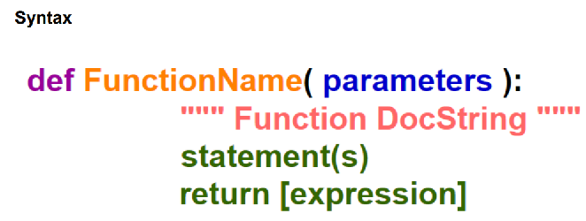

# Diffrent type of arguments-

 Required arguments

 Keyword arguments

 Default arguments

 Variable-length arguments

```python
#FUnction without arguments

def myfunc():
 print("Hello Python Lovers")
myfunc()
```

```
Hello Python Lovers
```

```python
#FUnction with arguments but No return value

def details(name,userid,country): # Function to print User details
 print('Name :- ', name)
 print('User ID is :- ', userid)
 print('Country :- ',country)

details('John' , 'john123' , 'India')
```

```
Name :-  John
User ID is :-  john123
Country :-  India
```

```python
#FUnction with arguments and return value

def square (n): #function to find square of a number
 n= n*n
 return n
square (10)
```

```
100
```

```python
#Even odd test

def even_odd (num):
 """ This function will check whether a number is even or odd"""
 if num % 2 ==0:
        print (num, ' is even number')
 else:
    print (num, ' is odd number')
even_odd(3)
even_odd(4)
print(even_odd.__doc__) # Print function documentation string
```

```
3  is odd number
4  is even number
 This function will check whether a number is even or odd
```

```python
def fullname (firstname , middlename ,lastname): #Concatenate Strings
 #fullname = "{} {} {}".format(firstname,middlename,lastname)
 fullname = f"{firstname} {middlename} {lastname}"

 print (fullname)
fullname('John' , 'Smith' , 'coder')
```

```
John Smith coder
```

```python
def fullname (firstname , middlename ,lastname): #Concatenate Strings
 #fullname = "{} {} {}".format(firstname,middlename,lastname)
 fullname = f"{firstname} {middlename} {lastname}"
 print (fullname)
fullname(lastname = 'coder' , middlename='Smith' , firstname='John') # Keyword Arguments
```

```
John Smith coder
```

```python
fullname ('John') # This will throw error as function is expecting 3 arguments.
```

```
---------------------------------------------------------------------------
TypeError                                 Traceback (most recent call last)
~\AppData\Local\Temp\ipykernel_14596\3391364419.py in <module>
----> 1 fullname ('John') # This will throw error as function is expecting 3 arguments.

TypeError: fullname() missing 2 required positional arguments: 'middlename' and 'lastname'
```

```python
def myfunc(city = 'Mumbai'):           # When a function is called without an argument it will use default value
 print('Most Populous City :- ', city)

myfunc()
```

```
Most Populous City :-  Mumbai
```

```python
#Scopes

var1 = 100           # Variable with Global scope.
def myfunc():
 print("valuein side funcntion",var1)        # Value 100 will be displayed due to global scope of var1

myfunc()
print("global value",var1)
```

```
valuein side funcntion 100
global value 100
```

```python
def myfunc1():
 var2 = 10 # Variable with Local scope
 print(var2)
def myfunc2():
 print(var2) # This will throw error because var2 has a local scope. Var2 is o
myfunc1()
myfunc2()
```

```
10
```

```
---------------------------------------------------------------------------
NameError                                 Traceback (most recent call last)
~\AppData\Local\Temp\ipykernel_6636\4262771634.py in <module>
      5  print(var2) # This will throw error because var2 has a local scope. Var2 is o
      6 myfunc1()
----> 7 myfunc2()

~\AppData\Local\Temp\ipykernel_6636\4262771634.py in myfunc2()
      3  print(var2)
      4 def myfunc2():
----> 5  print(var2) # This will throw error because var2 has a local scope. Var2 is o
      6 myfunc1()
      7 myfunc2()

NameError: name 'var2' is not defined
```

```python
var1 = 100 # Variable with Global scope.
def myfunc():
 var1 = 99 # Local scope
 print(var1)

myfunc()
print(var1) # The original value of var1 (100) will be retained due to global sc
```

```
99
100
```

```python
list1 = [11,22,33,44,55]
def myfunc(list1):
 del list1[0]
print('"List1" before calling the function:- ',list1)
myfunc(list1) # Pass by reference (Any change in the parameter within the function)
print('"List1" after calling the function:- ',list1)
```

```
"List1" before calling the function:-  [11, 22, 33, 44, 55]
"List1" after calling the function:-  [22, 33, 44, 55]
```

```python
list1 = [11,22,33,44,55]
def myfunc(list1):
    list1.append(100)

print('"List1" before calling the function:- ',list1)
myfunc(list1) # Pass by reference (Any change in the parameter within the functi
print('"List1" after calling the function:- ',list1)
```

```
"List1" before calling the function:-  [11, 22, 33, 44, 55]
"List1" after calling the function:-  [11, 22, 33, 44, 55, 100]
```

```python
list1 = [11,22,33,44,55]
def myfunc(list1):
 list1 = [10,100,1000,10000] # link of 'list1' with previous object is broken
 print('"List1" inside myfunc function:- ',list1)
print('"List1" before calling the function:- ',list1)
myfunc(list1) # Pass by reference (Any change in the parameter within the function
print('"List1" after calling the function:- ',list1)
```

```
"List1" before calling the function:-  [11, 22, 33, 44, 55]
"List1" inside myfunc function:-  [10, 100, 1000, 10000]
"List1" after calling the function:-  [11, 22, 33, 44, 55]
```

```python
def swap(a,b):
 temp = a
 a = b # link of 'a' with previous object is broken now as new object is
 b = temp # link of 'b' with previous object is broken now as new object is
 print(a,b)
a = 10
b = 20
swap(a,b)
a,b
```

```
20 10
```

```
(10, 20)
```

```python
def factorial(num): # Calculate factorial of a number using recursive function
 if num <=1 :
    return 1
 else:
        return num * factorial(num-1)

factorial(10)
```

```
3628800
```

```python
def add(num): # Sum of first n natural numbers
 if num == 0:
    return 0
 else:
        return num + add(num-1)
add(100) # Sum of first five natural numbers (1,2,3,4,5)
```

```
5050
```

```python
def fiboacci(num):
    if num <= 1:
        return num
    if num == 2:
        return 1
    else:
        return(fiboacci(num-1) + fiboacci(num-2))
nums = int(input("How many fibonacci numbers you want to generate -"))
for i in range(nums):
     print(fiboacci(i)) # Generate Fibonacci series
```

```
How many fibonacci numbers you want to generate -20
0
1
1
2
3
5
8
13
21
34
55
89
144
233
377
610
987
1597
2584
4181
```

# *args

When we are not sure about the number of arguments being passed to a function then we can use *args as function parameter

*args allow us to pass the variable number of Non Keyword Arguments to function.

We can simply use an asterisk * before the parameter name to pass variable length arguments.

The arguments are always passed as a tuple.

We can rename it to anything as long as it is preceded by a single asterisk (*). It's best

practice to keep naming it args to make it immediately recognizable.

# **kwargs

**kwargs allows us to pass the variable number of Keyword Arguments to the function.

We can simply use an double asterisk ** before the parameter name to pass variable length arguments.

The arguments are passed as a dictionary.

We can rename it to anything as long as it is preceded by a double asterisk (**). It's best practice to keep naming it kwargs to make it immediately recognizable.

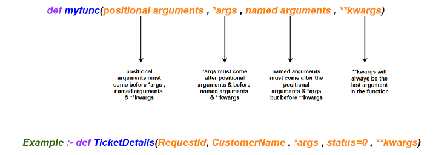

```python
#positional args

def add(a,b,c):
 return a+b+c

print(add(10,20,30)) # Sum of three number
```

```
60
```

```python
print(add(1,2,3,4)) '''This will throw below error as this function will only
take 3 args
If we want to make argument list dynamic then *args wil come in picture'''
```

```
  File "C:\Users\senth\AppData\Local\Temp\ipykernel_14916\4179749356.py", line 1
    print(add(1,2,3,4)) '''This will throw below error as this function will only
                        ^
SyntaxError: invalid syntax
```

```python
# *args will take dynamic argument list.
#So add() function will add the values in the list

def add(*args):
 return sum(args)
print(add(1,2,3))
print(add(1,2,3,4))
print(add(1,2,3,4,5))
print(add(1,2,3,4,5,6))
print(add(1,2,3,4,5,6,7))
```

```
6
10
15
21
28
```

```python
list1 = [1,2,3,4,5,6,7]
tuple1 = (1,2,3,4,5,6,7)
add(*list1) , add(*tuple1) #tuple & list items will be passed as argument list
```

```
(28, 28)
```

```python
#All four lists are unpacked and each indvidual value passed to thde funcion

list1 = [1,2,3,4,5,6,7]
list2 = [1,2,3,4,5,6,7]
list3 = [1,2,3,4,5,6,7]
list4 = [1,2,3,4,5,6,7]

add1(*list1 , *list2 , *list3 , *list4 )
```

[output not shown]

```python
def UserDetails(*args):
 print(args)
UserDetails('John' , 7412 , 600117 , 33 , 'India' , 'Tamil')
''' For the above example we cannot able to conclude about the parameters passed
e.g 'John' , 7412 , 41102 , 33 , 'India' , 'Tamil'
 In such cases we can take help of Keyworded arguments (**kwargs) '''
```

```
('John', 7412, 600117, 33, 'India', 'Tamil')
```

```
" For the above example we cannot able to conclude about the parameters passed \ne.g 'John' , 7412 , 41102 , 33 , 'India' , 'Tamil'\n In such cases we can take help of Keyworded arguments (**kwargs) "
```

```python
def UserDetails(**kwargs):
 for key,val in kwargs.items():
     print(f"{key}:-    {val}")
UserDetails(Name='John' , ID=7412 , Pincode=600117 , Age= 33 , Country= 'India')
```

```
Name:-    John
ID:-    7412
Pincode:-    600117
Age:-    33
Country:-    India
```

```python
mydict = {'Name': 'John', 'ID': 7412, 'Pincode': 600117, 'Age': 33, 'Country': 'India'}
UserDetails(**mydict)
```

```
Name:-    John
ID:-    7412
Pincode:-    600117
Age:-    33
Country:-    India
```

```python
def UserDetails(licenseNo, *args , phoneNo=0, **kwargs): # Using all four arguments:
    print("Nothing")
```

```python
 # This will fail. *args MUST come after positional arguments(licenseNo)
def UserDetails(licenseNo, **kwargs , *args):
 print('Nothing')
```

```
  File "C:\Users\senth\AppData\Local\Temp\ipykernel_12828\2900124712.py", line 2
    def UserDetails(licenseNo, **kwargs , *args):
                                          ^
SyntaxError: invalid syntax
```

```python
#corrected
def UserDetails(licenseNo,  *args, **kwargs ,):
 print('Nothing')
```

```python
#The below function will fail.
#positional argument (licenseNo) Mwill come first
def UserDetails(ID = 1, licenseNo, *args):
 print('Nothing')
```

```
  File "C:\Users\senth\AppData\Local\Temp\ipykernel_12828\2601365147.py", line 3
    def UserDetails(ID = 1, licenseNo, *args):
                                       ^
SyntaxError: non-default argument follows default argument
```

```python
#corrected
def UserDetails(licenseNo,ID = 1,  *args):
 print('Nothing')
```

# Lambda, Filter, Map and Reduce

# Lambda

A lambda function is an anonymous function (function without a name).

Lambda functions can have any number of arguments but only one expression. The expression is evaluated and returned.

We use lambda functions when we require a nameless function for a short period of time.

# Syntax:-

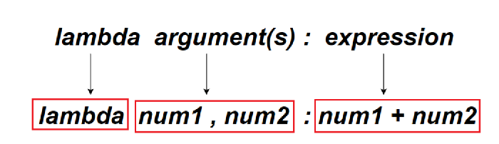

```python
 # This lambda function adds value 10 to an argument

addition = lambda a : a + 10
print(addition(5))
```

```
15
```

```python
#This lambda function takes two arguments (a,b) and mutiplies

product = lambda a, b : a * b
print(product(5, 6))
```

```
30
```

```python
#This lambda function takes three argument and add
addition = lambda a, b, c : a + b + c #This lambda function takes three argument
print(addition(5, 6, 2))
```

```
13
```

```python
# This lambda function can take any number of arguments

res = (lambda *args: sum(args))
res(10,20) , res(10,20,30,40) , res(10,20,30,40,50,60,70)
```

```
(30, 100, 280)
```

```python
# This lambda function can take an variable length args passed as dict

res1 = (lambda **kwargs: sum(kwargs.values()))
res1(a = 10 , b= 20 , c = 30) , res1(a = 10 , b= 20 , c = 30, d = 40 , e = 50)
```

```
(60, 150)
```

```python
# User defined function to find product of numbers

def product(nums):
    total = 1
    for i in nums:
        total *= i
    return total

# This lambda function can take any number of arguments and return thier product(User defined function).

res1 = (lambda **kwargs: product(kwargs.values()))
res1(a = 10 , b= 20 , c = 30) , res1(a = 10 , b= 20 , c = 30, d = 40 , e = 50)
```

```
(6000, 12000000)
```

```python
def myfunc(n):
 return lambda a : a + n
add10 = myfunc(10)
add20 = myfunc(20)
add30 = myfunc(30)
print(add10(5))
print(add20(5))
print(add30(5))
```

```
15
25
35
```

# Filter

It is used to filter the iterables/sequence as per the conditions.

Filter function filters the original iterable and passes the items that returns True for the function provided to filter.

It is normally used with Lambda functions to filter list, tuple, or sets.

# filter() method takes two parameters:

function - function tests if elements of an iterable returns true or false

iterable - Sequence which needs to be filtered, could be sets, lists, tuples, or any iterators

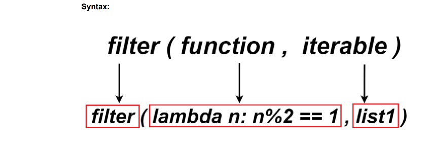

```python
list1 = [1,2,3,4,5,6,7,8,9]
def odd(n):
    if n%2 ==1:
        return True
    else:
        return False
# This Filter function filters list1 and passes only list of odd numbers

odd_num = list(filter(odd,list1))


odd_num
```

```
[1, 3, 5, 7, 9]
```

```python
list1 = [1,2,3,4,5,6,7,8,9]

# The below Filter function filters "list1" and passes all odd numbers using lambda

odd_num = list(filter(lambda n: n%2 ==1 ,list1))
odd_num
```

```
[1, 3, 5, 7, 9]
```

# Map

The map() function applies a given function to each item of an iterable (list, tuple etc.) and returns a list of the results.

# map() function takes two Parameters :

function : The function to execute for each item of given iterable.

iterable : It is a iterable which is to be mapped.

Returns :

```
Returns a list of the results after applying the given function to each item of a given
```

iterable (list, tuple etc.)

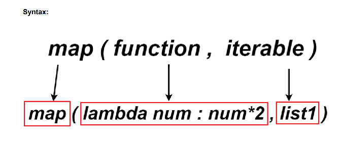

```python
def twice(n):
    return n*2

doubles = list(map(twice,odd_num)) # The map function will apply user defined "twice"S
doubles
```

```
[2, 6, 10, 14, 18]
```

```python
doubles = list(map(lambda n:n*2,odd_num)) # This map function will double all items inthe itretion
doubles
```

```
[2, 6, 10, 14, 18]
```

# Reduce

The reduce() function is defined in the functools python module.

The reduce() function receives two arguments, a function and an iterable. However, it doesn't return another iterable,nstead it returns a single value.

```python
from functools import reduce
def add(a,b):
 return a+b

sum_all = reduce(add,doubles)# This reduce function will perform sum of all item
sum_all
```

```
50
```

```python
#The below reduce() function will perform sum of all items in the list using lambda
sum_all = reduce(lambda a,b : a+b,doubles)
sum_all
```

```
50
```

```python
# Putting all together
sum_all = reduce(lambda a,b : a+b,list(map(lambda n:n*2,list(filter(lambda n: n%2==1,list1)))))
sum_all
```

```
50
```

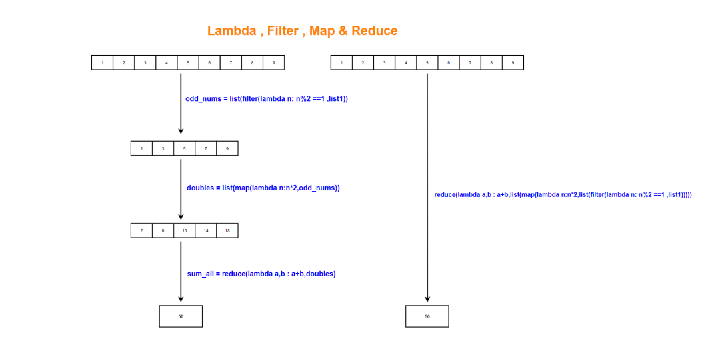

```python
# More examples on Map , Filter , Reduce
list1 = [1,2,3,4,5,6,7,8,9,10]
list(filter(lambda n: n%2 == 0, list1))
```

```
[2, 4, 6, 8, 10]
```

```python
list(filter(lambda n: n%2 != 0, list1))
```

```
[1, 3, 5, 7, 9]
```

```python
list1 = [1,2,3,4]
list2 = [5,6,7,8]

def double(x):
    return x+x

def add(x,y):
    return x+y

def square(x):
    return x*x

print('---------------')
print(list(map(double, list1))) # Double each number using map & User defined fun
print(list(map(add, list1, list2))) # add two items using map & User defined fun
print(list(map(square, list1))) #Square numbers using map & User defined function
print('---------------')
```

```
---------------
[2, 4, 6, 8]
[6, 8, 10, 12]
[1, 4, 9, 16]
---------------
```

```python
print('---------------')
print(list(map(lambda x: x + x, list1))) # Double each number using map & lambda
print(list(map(lambda x, y: x + y, list1, list2))) # add two items using map & l
print(list(map(lambda x: x*x, list1))) #Square numbers using map & lambda
print('---------------')
```

```
---------------
[2, 4, 6, 8]
[6, 8, 10, 12]
[1, 4, 9, 16]
---------------
```

# Classes & Objects

# Class:

A Class is an object constructor or a "blueprint" for creating objects.

IT has atributes ( data or data member) and methods (functions) accessed via dot notation.

# Class variable - atributes - data or data member :

A variable that is shared by all instances of a class.

Class variables are defined within a class but outside any of the class's methods. Class variables are not used as frequently as instance variables are.

# Object:

A unique instance of a data structure that is defined by its class.

An object comprises both data members (class variables and instance variables) and methods.

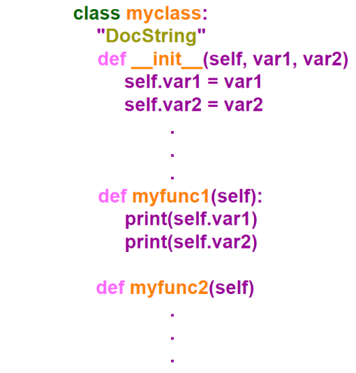

```python
# Create a class with property "var1"
class myclass:
 var1 = 10

obj1 = myclass() # Create an object of class "myclass()"
print(obj1.var1)
```

```
10
```

# Method :

A special kind of function that is defined in a class definition.

Methods can access inside the class

# Instance:

An individual object of a certain class. An object obj that belongs to a class Circle

# Instance variable:

A variable that is defined inside a method and belongs only to the current instance of a class.

```python
class Employee:
    def asgin_empdetails(self, name, empid):
        # Instance variable
        self.name = name
        self.empid = empid
        #self.greet()

    def greet(self): # Class Method
        print(f"Thanks for joining ABC Company {self.name}!!")
        print(f"Your Employee id is  {self.empid}!!")

emp1 = Employee() # Create an employee object
emp2 =  Employee()

emp1.asgin_empdetails("Json", 34163)
emp1.greet()

emp2.asgin_empdetails("manson", 34164)
emp2.greet()
```

```
Thanks for joining ABC Company Json!!
Your Employee id is  34163!!
Thanks for joining ABC Company manson!!
Your Employee id is  34164!!
```